# Classification Bayésienne et AFD

Paul Cascarino et Mathis Quinio-Cosquer

Janvier 2023

# Projet 3 :

## 1. Introduction

### Les objectifs du projet

Le but de ce projet est de réduire la dimensionnalité des données sur le thèses de doctorat françaisee afin d’effectuer une classification bayesienne sur la nature textuelle et sémantique des données.

Ainsi nous devons mettre en place une classification bayésienne avancé avec AFD afin de les catégoriser en domaines d’étude.

## 2. Chargement et exploration des données

### Préparation et imports

Dans un premier temps, nous effaçons la mémoire :

```r
rm(list=ls())
```

Et faisons les chargements des packages nécessaires :

```r
library(dplyr)
```

```r
library(ggplot2)
library(stringr)

# Permet la tokenization : https://smltar.com/tokenization#types-of-tokens
library(tokenizers)
# Permet l'utilisation de liste pour le stop-words : https://smltar.com/stopwords#premadestopwords
library(stopwords)
# Permet la stemmatization : https://smltar.com/stemming#how-to-stem-text-in-r
library(SnowballC)

library(tm)
library(text2vec)
library(slam)

# Installer et charger le package 'MASS' pour l'Analyse Discriminante Linéaire (LDA)
# install.packages("MASS")
library(MASS)
```

### Chargement et exploration des données

Les données sont récupérés sur le site kaggle à l’adresse : https://www.kaggle.com/code/antoinebourgois2/4-french-doctoral-theses-semantic-search-tool Nous pouvons ainsi récupérer le csv récupéré avec :

```r
df <- read.csv('data/french_thesis_20231021_metadata.csv')
dim(df)
```

```
## [1] 519578      8
```

```r
df <- subset(df, !(is.na(Description) | Description == ""))
df <- subset(df, !(is.na(Title) | Title == ""))
dim(df)
```

```
## [1] 414553      8
```

```r
head(df)
```

```
##             URL
## 3  1973NAN10113
## 16 1984PA112254
## 18 1984NAN10361
## 32 1985LIL10009
## 39 1985DIJOS057
## 41 1985PA112335
##                                                                                                                                                                                                                                            Title
## 3                                                                                                                                                                                                                                Lymphocytologie
## 16                                                                        Étude de l'influence des nucléons de valence sur le mécanisme de fusion entre les noyaux de la couche 1p et 2s-1d pour des énergies incidentes variant de 2 à 10 Mev/u
## 18                                                                                                                                                             Étude de l'insertion dans le graphite de métaux alcalins lourds alliés au bismuth
## 32                                                                                                                                         Contribution à l'étude de spinelles de synthèse et de chromites naturelles par microsonde raman laser
## 39                                                                                                                                       Influence de divers additifs sur la germination-croissance de la phase Cu3Si formée par réaction Si-CuC
## 41 Modèle de bandes de diverses phases lamellaires MPS₃ : étude EXAFS de quelques modifications structurales induites par substitution et intercalation : conséquences spectroscopiques et magnétiques dans le cas type des phases Nix M'1-x PS₃
##                      Author
```

[output cut: 27 more lines]

Réduisons notre df:

```r
dim(df)
```

```
## [1] 414553      8
```

```r
set.seed(13)

nbr_row_little_df <- 10000

little_df <- df[sample(nrow(df), nbr_row_little_df),]

dim(little_df)
```

```
## [1] 10000     8
```

Et un dataframe réduit (‘little_df’) avec : - ‘nbr_row_little_df’ lignes - 8 colonnes

Regardons les noms des colonnes :

```r
colnames(df)
```

```
## [1] "URL"         "Title"       "Author"      "Description" "Direction"
## [6] "Domain"      "Statuts"     "Date"
```

Nous avons les colonnes :

- **URL** : L url de la thèse
- **Title** : Le titre de la thèse
- **Author** : L auteur de la thèse (catégorielle)
- **Description** : La description de la thèse
- **Direction** : Le directeur de thèse et son id (catégorielle)
- **Domain** : Le domaine de la thèse (catégorielle)
- **Statuts** : Le status de la thèse (catégorielle)
- **Date** : La date de la thèse

Convertissons nos variables catégorielles en facteurs :

```r
df$Author <- as.factor(df$Author)
df$Domain <- as.factor(df$Domain)
df$Statuts <- as.factor(df$Statuts)
df$Direction <- as.factor(df$Direction)

little_df$Author <- as.factor(little_df$Author)
little_df$Domain <- as.factor(little_df$Domain)
little_df$Statuts <- as.factor(little_df$Statuts)
little_df$Direction <- as.factor(little_df$Direction)

cat('Nombre d auteurs : ',length(levels(df$Author)))
```

```
## Nombre d auteurs :  401573
```

```r
cat('Nombre de domaines : ',length(levels(df$Domain)))
```

```
## Nombre de domaines :  24736
```

```r
cat('Les différents statuts : ',levels(df$Statuts))
```

```
## Les différents statuts :  En préparation Soutenue
```

```r
cat('Nombre des directeurs de thèse : ',length(levels(df$Direction)))
```

```
## Nombre des directeurs de thèse :  171845
```

### Nettoyage des données textuelles

Nous avons 2 colonnes avec des données textuelles non catégorielle : **Title** et **Description**

Pour nétoyer nous allons créer une fonction qui vas : - mettre tous les textes en minuscule - supprimer les chiffres - supprimer tous les caractères spéciaux

```r
clean_text <- function(df_col){
  temp_col <- str_to_lower(df_col)
  temp_col <- str_replace_all(temp_col, "'", " ")
  temp_col <- str_replace_all(temp_col, "[0-9]", "")
  temp_col <- str_replace_all(temp_col, "[^[:alnum:][:space:]]", "")

  return(temp_col)
}

# df$Title_tidy <- clean_text(df$Title)
# df$Description_tidy <- clean_text(df$Description)

little_df$Title_tidy <- clean_text(little_df$Title)
little_df$Description_tidy <- clean_text(little_df$Description)

head(df$Title_tidy)
```

La fonction **clean_text** nous permet de supprimer les caractères non alphanumériques et les chiffres ainsi que de touus mettre en minuscule.

Nous pouvons maintenant apppliquer la Tokenization :

#### Tokenization

https://smltar.com/tokenization

Nous décidons dans un premier temps de faire une tokenization par mots car c est la méthode la plus commune et que cela nous parait logique de travailler dans un premier temps avec les mots.

De plus nous avons vu grâce au mini projet 1 que c’est la plus performante par rapports à la tokenization ppar pluusieurs mots en terme d’accuracy :

```r
# df$Title_token <- tokenize_words(df$Title_tidy)
# df$Description_token <- tokenize_words(df$Description_tidy)

little_df$Title_token <- tokenize_words(little_df$Title_tidy)
little_df$Description_token <- tokenize_words(little_df$Description_tidy)

head(little_df$Title_token)
```

```
## [[1]]
##  [1] "la"                "dialectalisation"  "hispanique"
##  [4] "dans"              "une"               "perspective"
##  [7] "sociolinguistique" "étude"             "sur"
## [10] "la"                "langue"            "des"
## [13] "migrants"
##
## [[2]]
##  [1] "développement" "d"             "une"           "nouvelle"
##  [5] "technique"     "de"            "mesure"        "hodoscopique"
##  [9] "encoeur"       "exploitant"    "le"            "signal"
## [13] "optique"       "d"             "un"            "détecteur"
## [17] "neutronique"   "à"             "gaz"           "de"
## [21] "remplissage"
##
## [[3]]
## [1] "polymersomes" "à"            "propriété"    "d"            "émission"
## [6] "induite"      "par"          "l"            "agrégation"
##
## [[4]]
## [1] "le"             "particularisme" "de"             "la"
## [5] "preuve"         "en"             "droit"          "du"
## [9] "travail"
##
## [[5]]
##  [1] "étude"           "théorique"       "et"              "expérimentale"
##  [5] "d"               "un"              "nouveau"         "procédé"
##  [9] "multicolonnes"   "continu"         "de"              "chromatographie"
## [13] "préparative"     "intégrant"       "une"             "étape"
## [17] "de"              "concentration"
##
## [[6]]
##  [1] "ruralité"    "et"          "agriculture" "au"          "prisme"
##  [6] "des"         "mobilités"   "spatiales"   "laltiplano"  "sud"
## [11] "de"          "la"          "bolivie"     "à"           "lheure"
## [16] "du"          "boom"        "de"          "la"          "quinoa"
```

Nous pouvons maintenant observer les tokens les plus utilisés :

Utilisons la fonction du mini-projet 1 :

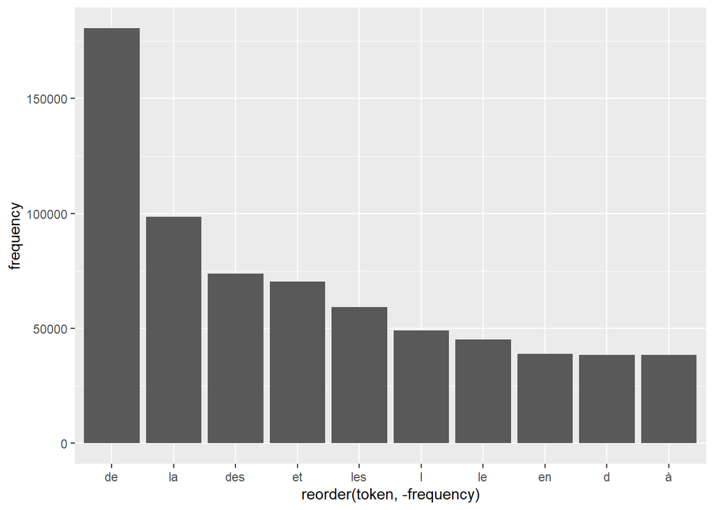

```r
give_most_words <- function(df_tokens, col_names, n){
  token_freq <- table(unlist(df_tokens[[col_names]]))
  token_freq_df <- data.frame(token = names(token_freq), frequency = as.numeric(token_freq))
  token_freq_df <- token_freq_df[order(-token_freq_df$frequency),]
  plot <- ggplot(token_freq_df[0:n,], aes(x=reorder(token, -frequency), y=frequency)) +
            geom_bar(stat = 'identity')
  return(list(plot=plot, df=token_freq_df))
}
result <- give_most_words(little_df[, c('Description_token', 'Domain')], 'Description_token', 10)
result1 <- give_most_words(little_df[, c('Title_token', 'Domain')], 'Title_token', 10)

result$plot
```

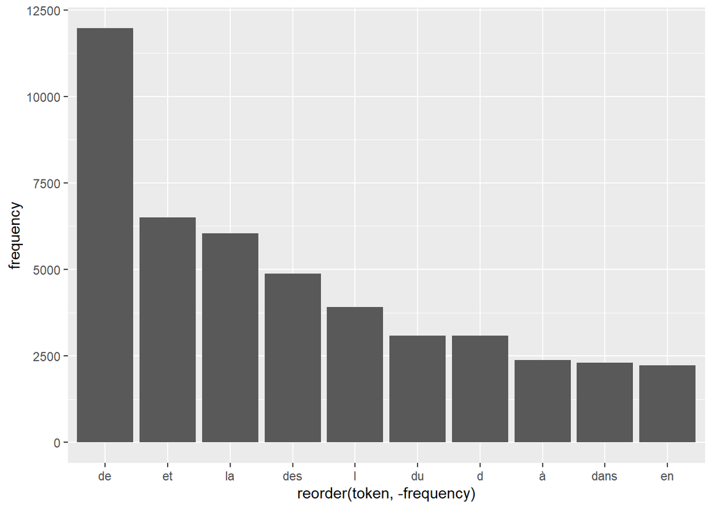

```r
result1$plot
```

**Explication :**

Nous avons définit une fonction qui permet de retourner un graph des n premiers mots et longeurs fréquences d apparition dans notre df.

Nous remarquons que nous avons une liste de mots inutiles. Regardons maintenant les stop words :

##### Stop words

Les **stop words** sont les mots qui n ont pas d intérêts dans le sens de la phrase. Ansi les supprimer réduirait le nombre de feature et donc le nombre de calculs. Nous pouvons aussi penser que réduire les mots inutiles réduirait la performance de notre futur modèle.

Pour cela nous allons utiliser une liste de stop words déjà faite, Nous allons donc utiliser la bibliothèque **stopwords-iso** en français.

```r
stopwords::stopwords_getlanguages("stopwords-iso")
```

```
##  [1] "af" "ar" "hy" "eu" "bn" "br" "bg" "ca" "zh" "hr" "cs" "da" "nl" "en" "eo"
## [16] "et" "fi" "fr" "gl" "de" "el" "ha" "he" "hi" "hu" "id" "ga" "it" "ja" "ko"
## [31] "ku" "la" "lt" "lv" "ms" "mr" "no" "fa" "pl" "pt" "ro" "ru" "sk" "sl" "so"
## [46] "st" "es" "sw" "sv" "th" "tl" "tr" "uk" "ur" "vi" "yo" "zu"
```

Nous observons que nouus avons bien le français avec ‘fr’

```r
head(stopwords::stopwords("fr", source = "stopwords-iso"))
```

```
## [1] "a"          "abord"      "absolument" "afin"       "ah"
## [6] "ai"
```

```r
cat("Nombre de mots des Titres avant l'étape des stop words : ",
sum(lengths(df$Title_token)))
```

```
## Nombre de mots des Titres avant l'étape des stop words :  0
```

```r
cat("Nombre de mots des Description avant l'étape des stop words : ",
sum(lengths(df$Description_token)))
```

```
## Nombre de mots des Description avant l'étape des stop words :  0
```

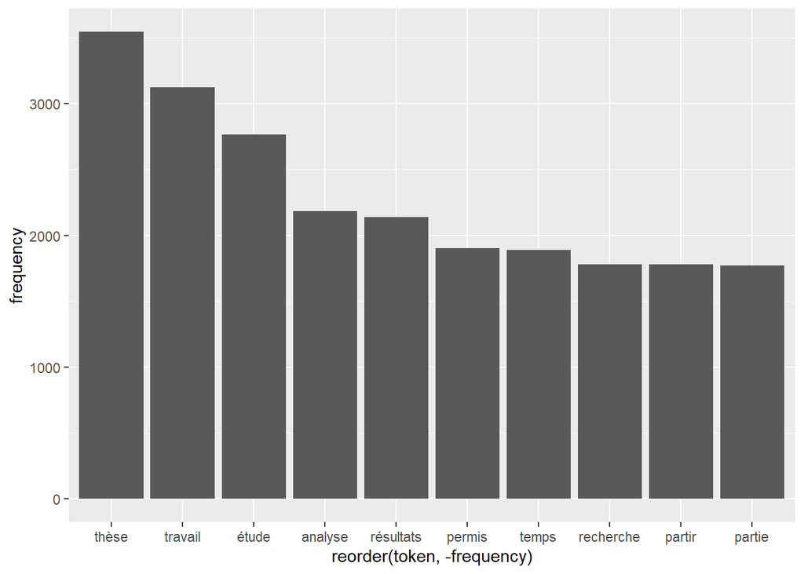

```r
# df$Title_token <- sapply(df$Title_token, function(x) setdiff(x, stopwords::stopwords("fr", source = "stopwords-iso")))
# df$Description_token <- sapply(df$Description_token, function(x) setdiff(x, stopwords::stopwords("fr", source = "stopwords-iso")))

little_df$Title_token <- sapply(little_df$Title_token, function(x) setdiff(x, stopwords::stopwords("fr", source = "stopwords-iso")))
little_df$Description_token <- sapply(little_df$Description_token, function(x) setdiff(x, stopwords::stopwords("fr", source = "stopwords-iso")))


result <- give_most_words(little_df[, c('Description_token', 'Domain')], 'Description_token', 10)
result1 <- give_most_words(little_df[, c('Title_token', 'Domain')], 'Title_token', 10)

result$plot
```

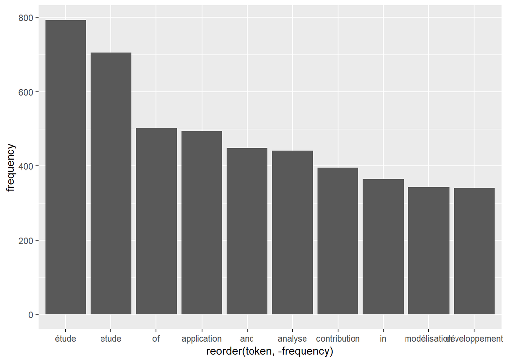

```r
result1$plot
```

```r
cat("Nombre de mots des Titres après l'étape des stop words : ",
sum(lengths(little_df$Title_token)))
```

```
## Nombre de mots des Titres après l'étape des stop words :  88311
```

```r
cat("Nombre de mots des Description après l'étape des stop words : ",
sum(lengths(little_df$Description_token)))
```

```
## Nombre de mots des Description après l'étape des stop words :  982730
```

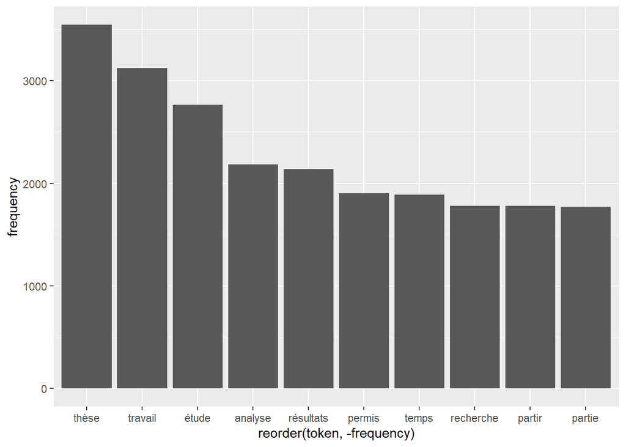

```r
result$plot
```

##### Stemming

Le stemming permet de rapprocher les mots similaires tel que ‘feel’ et ‘feels’ en un stem qui est un mot de base (ex:‘feel’).

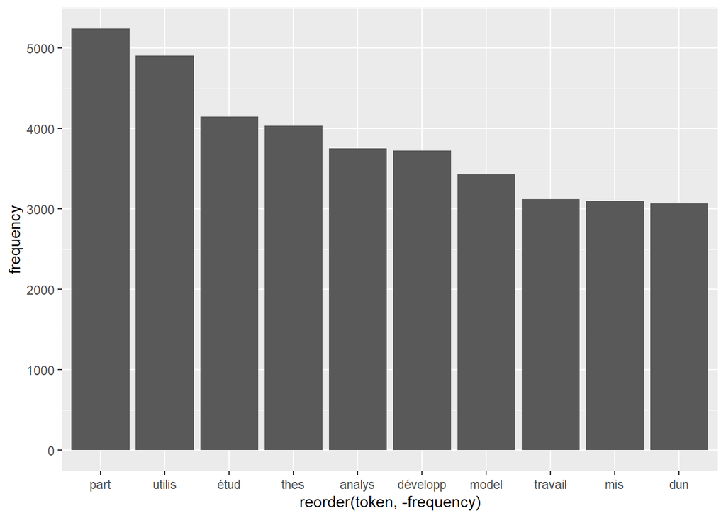

```r
little_df$Title_token <- lapply(little_df$Title_token, function(x) wordStem(x, language = "french"))
little_df$Description_token <- lapply(little_df$Description_token, function(x) wordStem(x, language = "french"))

result <- give_most_words(little_df[, c('Description_token', 'Domain')], 'Description_token', 10)
result1 <- give_most_words(little_df[, c('Title_token', 'Domain')], 'Title_token', 10)

result$plot
```

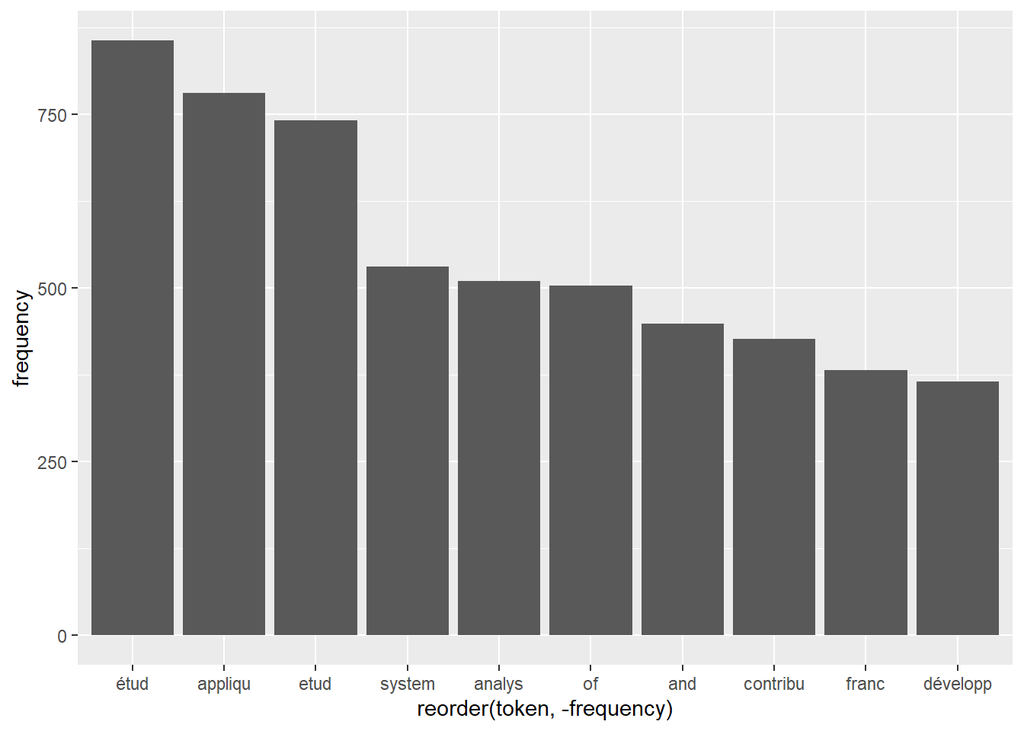

```r
result1$plot
```

Nous remarquons que nous avons rassembler des mots similaires entre eux.

On a :
$$\text{IDF}(t, D) = \log\left(\frac{N}{\text{df}(t)}\right)$$
avec

- N : le nombre documents total
- df(t) : le nombre de documents comportant le terme t

Ainsi IDF(t,D) donne le poids IDF du terme t dans les documents de D. Cela correspond à l importance du mot dans notre corpus de documents.

```r
give_tfidf <- function(ldf, term_count_min){

    # Créer un itoken
  itoken_Description <- itoken(ldf$Description_token)
  itoken_Tittle <- itoken(ldf$Title_token)

  # Créer le vocabulaire
  vocabulary_Description <- create_vocabulary(itoken_Description)
  vocabulary_Tittle <- create_vocabulary(itoken_Tittle)

  vocabulary_Description <- prune_vocabulary(vocabulary_Description, term_count_min)
  vocabulary_Tittle <- prune_vocabulary(vocabulary_Tittle, term_count_min)

  vectorizer_Description <- vocab_vectorizer(vocabulary_Description)
  vectorizer_Tittle <- vocab_vectorizer(vocabulary_Tittle)

  dtm_Description <- create_dtm(itoken_Description, vectorizer_Description)
  dtm_Tittle <- create_dtm(itoken_Tittle, vectorizer_Tittle)

  Description_matrix <- as.matrix(as(dtm_Description, "CsparseMatrix"))
  Tittle_matrix <- as.matrix(as(dtm_Tittle, "CsparseMatrix"))

  return(list(Description= Description_matrix, Tittle = Tittle_matrix))
}
tfidfs <- give_tfidf(little_df, 5)
little_df$tfidf_Description <- tfidfs$Description
little_df$tfidf_Tittle <- tfidfs$Tittle
```

## 3. Extraction de caractéristique et réduction de dimensionnalité

### Appliquez la modélisation thématique (topic modeling) si nécessaire.

```r
# library(tm)
# library(topicmodels)


# tfidf_matrix <- as.matrix(tfidfs$Description)


# num_topics <- 5


# lda_model <- LDA(tfidf_matrix, k = num_topics, control = list(seed = 1234))


# terms(lda_model)


# doc_topics <- as.matrix(topics(lda_model, 1))
# head(doc_topics)
```

### LDA

```r
# X <- cbind(little_df$tfidf_Description, little_df$tfidf_Tittle, little_df$Domain)

# lda_result <- MASS::lda(X, method = "moment")


# lda_features <- predict(lda_result)$x


# print(lda_result)
```

```r
# selected_columns <- c("Domain", "tfidf_Description", "tfidf_Tittle")
# projected_data <- predict(afd_model, newdata = little_df[selected_columns])$x
```

## 4. Conclusion

Nous n’avons pas eu le temps de finir le projet à cause de trop nombreux problème, nous avons préféré accordé le temps restant au projet final…